# ABSTRACT

The vast majority of the population in developing and 3rd world countries make their ways to the Civil hospitals(run by government) whenever there’s an emergency because of their low cost of treatment, The problem with the civil hospitals is that they lack the resources needed to provide service to the big part of the population, there’s usually one or two of them in big cities and people all over the country especially from the far rural areas, cover 100s of miles to get the treatment, they sometimes end up waiting 3 days to well over a week while staying in the garden or a parking lot of the hospital. There are many cases where people lost their lives just because they couldn’t get the treatment at the right time. In this proposal I have proposed a method in which more patients are treated in an efficient manner so that more people are returned home happy and healthy. We have used a Queuing theory discussed briefly in the class for both the models and have modified it for our problem.

# INTRODUCTION

Health and sanitation, often times are the most overlooked sectors and the most suffering ones too in the poor countries, these are the countries where the fertility rate are high and the hospitals that are built couldn’t accommodate it.

LONDON (Reuters) - Over a third of hospitals and clinics in developing countries have nowhere for staff or patients to wash with soap, and almost 40 percent have no source of water, according to a WHO-backed international review published.

The rate at which people enter these hospitals is more than that of exiting, the long waiting lines at the hospitals have consequences far beyond that of just physical ones, It is dangerous for the individual’s mental health and even for the economy.

Waiting for health care also has broader economic consequences. Increased absenteeism, reduced productivity, and reduced ability to work caused by untreated medical conditions and waiting can reduce overall economic activity. One estimate pegged the economic cost of excess waiting for health care in 2007 (waiting beyond lengthy target wait times) for just four medical services1 at $14.8 billion, with another $4.4 billion in resulting reductions in governmental revenues (Centre for Spatial Economics, 2008).

Even though we are witnessing major breakthroughs in technologies nearly every day, there are still some people who in spite of being a patient and a part from waiting for the their turn, they struggle just to get their appointment scheduled, When the appointment or registration slips could be made simpler by introducing Online facility.

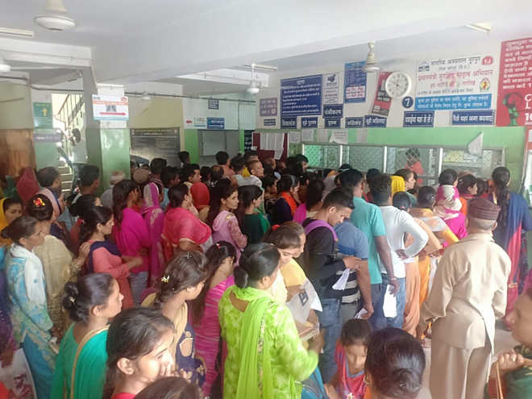

*Long queues at counters of registration in Nurpur Civil hospital(India).*

NO debate could be done on the long queues and mortality being correlated.

Sobolev et al. (2006a) examined the effect of wait times on patients set to receive coronary artery bypass surgeries (CABG). The results indicated that treatment delays can lead to an increased risk of death for all patients, includ-ing those whose condition was assessed as being of low severity during the planning phases of treatment. In a similar vein, Sobolev et al. (2006b) assessed the consequences of assigning CABG candidates to less urgent priority cat-egories and found that “longer delays in the nonurgent group contributed to a higher proportion of patients dying before surgery from all causes as com-pared with the semiurgent group” (2006b: 685). More recently, Sobolev et al. (2013) again emphasised the fact that “queuing patients according to urgency of treatment contributes to a higher proportion of preoperative death among CABG candidates in the less urgent category” (2013: 10).

We have made a small attempt to provide a better way to meet the increasing demand and decrease the waiting time at such hospitals, We have made a 2 simulation models of the hospitals, In model 1 we have only one treatment facility for the patients but in model 2 we add another facility so now there are two facilities for the patients. If the first facility is being used the patient will then be directed towards the facility two and vice versa. The simulation for both the models were simulated for 100 patients through which we have obtained some crucial statistics like average waiting time, max waiting time, how long it took to service 100 patients etc.

## Assumptions

We have made an assumption that the inter arrival time and time taken for treatment of the patient follows a uniform distribution in either model.

Service time ~ Uniform (10,100) in minutes

The service times varies from patient to patient, that’s why we have somewhat bigger range than inter arrival times I.e from 10 to 100 minutes.

*Note: These intervals for random numbers are based on observation.*

**The graph of the distribution of Inter arrival time and service time is in the last cell**

## 1st Model, A hospital with one treatment facility

This model is similar to the one discussed in class and is available in text book too, we have used a Monte-Carlo simulation algorithm to simulate a hospital where there’s only one facility,

### Fucntion for model 1

Our function **civil_one_facility** takes 5 positional arguments which are as follows

n which is actually the number of patients that were catered in this particular hospital, while bt1 and bt2 is the range of uniform random number for **Arrival time between patients**, next two are se1 and se2 which is used as a range for the uniform random number for **Service time of patients**.

In the first step we generated a pair of random numbers which are b1 and s1 short for **Between** and **Service** time for the first patient in the simulation, further we initialized all the output values, setting (wait time) as zero since the first patient doesn't have to wait. We then created the empty lists for the values that are needed for computations, we have also commented infront of it what each list holds, before creating the lists we have used **global** function so that these lists are available outside the function for cross checking. The initialized values are then stored in their respective lists by using the append function. Next steps are the most crucial and ones where the computations for patient 2,3,4......n are done, provided that the same values for patient 1 has already been done in the prior steps. In step 17 we are taking the average or calculating the ouput values that our function will return. The last step is preparing the data for output, since there's not a single value that is being returned therefore we chose to return all the values in list.

Output of this function are as follows and are in the same order:

1) Average time spent by a patient at hospital.

2) Maximum time spent by a patient at hospital.

3) Average waiting time of a patient.

4) Maximum waiting time.

```python
import random
import numpy as np
import pandas as pd
```

```python
def civil_one_faciltiy(n,bt1,bt2,se1,se2):

    #step 1
    b1=round(random.uniform(bt1,bt2))
    s1=round(random.uniform(se1,se2))
    arrive_1=b1

    #step 2
    idle1=arrive_1
#     finish1=arrive_1+s1
    total_time=s1
    max_hospital=s1
    wait_time=0
    max_wait=0
    idle_time=arrive_1

    #step 3
    finish1=arrive_1+s1

    #n=100

    global arrivals,idle,waiting,starting,finish,hospital,service,between

    arrivals=[] #for storing the arrival times of each patient
    idle=[]     #Stores the idle time at each iteration or every time the patient comes in to the hospital
    waiting=[]  #Waiting time for each patient
    starting=[] #Service starting time for the patients
    finish=[]   #Time taken to service a patient
    hospital=[] #Time spent by each patient in hospital
    service=[]  #Random number of service time
    between=[]  #Random number for the arrival between succesive patients

    arrivals.append(arrive_1)
    finish.append(finish1)
    idle.append(idle1)
    starting.append(arrive_1)
    waiting.append(wait_time)
    hospital.append(finish1)
    between.append(b1)
    service.append(s1)

    #step 4
    for i in range(1,n):
        #step 5
        between_i=round(random.uniform(bt1,bt2))
        service_i=round(random.uniform(se1,se2))

        between.append(between_i)
        service.append(service_i)
        #step 6
        arrive_i=arrivals[i-1]+between_i
        arrivals.append(arrive_i)

        #step 7
        timediff=arrive_i-finish[i-1]
        #print(timediff)

        #step 8
        if timediff>=0:
            idle_i=timediff
            wait_i=0
            idle.append(idle_i)
            waiting.append(wait_i)

        elif timediff<0:
            wait_i= -1*(timediff)
            idle_i=0
            idle.append(idle_i)
            waiting.append(wait_i)

        #step 9
        start_i=arrive_i+wait_i
        starting.append(start_i)

        #step 10
        finish_i=start_i+service_i
        finish.append(finish_i)

        #step 11
        hospital_i=wait_i+service_i
        hospital.append(hospital_i)

        #step 12
        total_time+=hospital_i

        #step 13
        if hospital_i>max_hospital:
            max_hospital=hospital_i

        #step 14
        wait_time+=wait_i

        #step 15
        idle_time+=idle_i

        #step 16
        if wait_i>max_wait:
            max_wait=wait_i

    #step 17
    total_time=total_time/n
    wait_time=wait_time/n
    idle_time=idle_time/finish[-1]

    #step 18
    values=[total_time,max_hospital,wait_time,max_wait]

    return values
```

#### Following is the glimpse of the data that we have obtained upon running our simulation, there are total of 100 of observations for each column I.e we simulated it for 100 patients. Data-frame from pandas is then created to display,

```python
z=civil_one_faciltiy(n=100,bt1=25,bt2=40,se1=10,se2=100)

resultss={"Patient":[i for i in range(1,101)], "Time between patients":between,'Arrival time':arrivals,
         "Start time":starting,"waiting time":waiting,
         "Service time":service,"Time in hospital":hospital,
         "Completion time":finish}

df2=pd.DataFrame(resultss)

print(z)
df2.head()
```

[output not shown]

|  | Patient | Time between patients | Arrival time | Start time | waiting time | Service time | Time in hospital | Completion time |
| --- | --- | --- | --- | --- | --- | --- | --- | --- |
| 0 | 1 | 32 | 32 | 32 | 0 | 100 | 132 | 132 |
| 1 | 2 | 31 | 63 | 132 | 69 | 58 | 127 | 190 |
| 2 | 3 | 31 | 94 | 190 | 96 | 98 | 194 | 288 |
| 3 | 4 | 37 | 131 | 288 | 157 | 61 | 218 | 349 |
| 4 | 5 | 38 | 169 | 349 | 180 | 19 | 199 | 368 |

#### The table below shows the summary of the above obtained observations.

```python
dff=pd.DataFrame(df2.describe())
dff
```

|  | Patient | Time between patients | Arrival time | Start time | waiting time | Service time | Time in hospital | Completion time |
| --- | --- | --- | --- | --- | --- | --- | --- | --- |
| count | 100.000000 | 100.000000 | 100.000000 | 100.000000 | 100.000000 | 100.00000 | 100.000000 | 100.000000 |
| mean | 50.500000 | 32.460000 | 1658.710000 | 2657.650000 | 998.940000 | 53.09000 | 1052.350000 | 2710.740000 |
| std | 29.011492 | 4.281555 | 942.716602 | 1493.940295 | 554.809619 | 25.15692 | 554.394827 | 1494.023032 |
| min | 1.000000 | 25.000000 | 32.000000 | 32.000000 | 0.000000 | 12.00000 | 127.000000 | 132.000000 |
| 25% | 25.750000 | 29.000000 | 854.000000 | 1446.000000 | 580.750000 | 34.75000 | 621.250000 | 1471.750000 |
| 50% | 50.500000 | 32.000000 | 1679.500000 | 2532.500000 | 860.500000 | 53.00000 | 904.500000 | 2576.000000 |
| 75% | 75.250000 | 36.000000 | 2458.250000 | 3884.750000 | 1426.500000 | 72.25000 | 1491.750000 | 3950.000000 |
| max | 100.000000 | 40.000000 | 3246.000000 | 5265.000000 | 2019.000000 | 100.00000 | 2095.000000 | 5341.000000 |

#### Below are some of the crucial statistics that we care about the most.

```python
df3=pd.DataFrame({"Results": ['Average time at the hospital','Maximum time at the hospital',
                             'Average waiting time at the hospital','Maximum waiting time at the hospital',
                             'Time taken by facility for 100 patients'],
                  "Values":[z[0],z[1],z[2],z[3],np.array(df2['Completion time'][-1:])[0]]
                  },index=[i for i in range(1,6)])
df3
```

|  | Results | Values |
| --- | --- | --- |
| 1 | Average time at the hospital | 1052 |
| 2 | Maximum time at the hospital | 2095 |
| 3 | Average waiting time at the hospital | 999 |
| 4 | Maximum waiting time at the hospital | 2019 |
| 5 | Time taken by facility for 100 patients | 5341 |

The results from the above table are awful, since the average waiting time at the hospital is **16.65** hours which is insane and at the same time usual for the people living in these countries. Our goal here is to reduce all of the values in this table.

## Checking the Distributions of each statistic

We ran 200 independent simulations to obtain 200 values of each statistic to determine what does the distribution of each statistic look like, note that we chose n=100 which is number of patients treated at the the hospital with one facility.

```python
avg_time=[]

max_time=[]

waiting_time=[]

max_wait=[]

for i in range(200):
    h=civil_one_faciltiy(n=100,bt1=25,bt2=40,se1=10,se2=100)
    avg_time.append(h[0])
    max_time.append(h[1])
    waiting_time.append(h[2])
    max_wait.append(h[3])
#     print(h[1])
```

```python
#Creating the dataframe.
df2=pd.DataFrame({'Average time at the hospital':np.array(avg_time),
                  'Maximum time at the hospital':np.array(max_time),
                  'Average waiting time':np.array(waiting_time),
                 'Maximum waiting time':np.array(max_wait),
                  },
                 index=[i for i in range(1,len(avg_time)+1)])
df2[:15]
```

|  | Average time at the hospital | Maximum time at the hospital | Average waiting time | Maximum waiting time |
| --- | --- | --- | --- | --- |
| 1 | 928.91 | 2083 | 876.71 | 2051 |
| 2 | 1221.52 | 2362 | 1165.80 | 2306 |
| 3 | 1160.61 | 1988 | 1108.81 | 1917 |
| 4 | 1292.07 | 2311 | 1237.40 | 2282 |
| 5 | 1218.92 | 2013 | 1166.36 | 1981 |
| 6 | 1063.30 | 2136 | 1009.46 | 2098 |
| 7 | 1042.84 | 2251 | 988.35 | 2187 |
| 8 | 1228.08 | 2543 | 1171.03 | 2487 |
| 9 | 1111.56 | 2238 | 1056.43 | 2189 |
| 10 | 1114.36 | 2416 | 1058.88 | 2324 |
| 11 | 1205.13 | 2002 | 1152.56 | 1974 |
| 12 | 1294.14 | 2262 | 1240.07 | 2230 |
| 13 | 1249.99 | 2394 | 1195.17 | 2348 |
| 14 | 906.91 | 1876 | 855.86 | 1794 |
| 15 | 1214.96 | 2501 | 1158.36 | 2401 |

## Plotting the Statisitcs

We used .hist() function to plot the histogram, to determine the distribution

```
array([[<matplotlib.axes._subplots.AxesSubplot object at 0x7faab03dc358>,
      dtype=object)
```

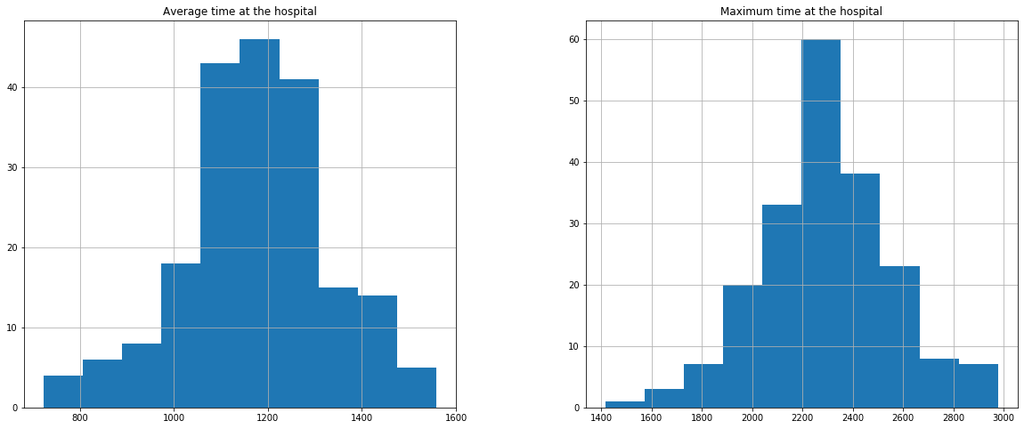

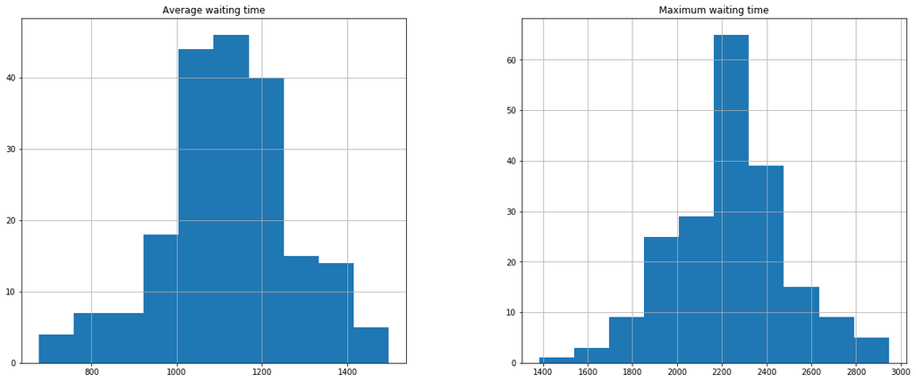

```python
df2.hist(column=['Average time at the hospital','Maximum time at the hospital'],figsize=(20,8))
df2.hist(column=['Average waiting time','Maximum waiting time'],figsize=(20,8))
```

All of the distributions nearly follow Normal or Gaussian distribution as they are centerd around some average value

# 2nd Model, A hospital with 2 treatment facilities

##### The model is similar to the model one, the only difference is that the later had one treatment facility and now we have total of two facilities. We have used a Monte-Carlo simulation algorithm to simulate a hospital where there are two treatment facilities.

### Function for Model 2

This function is similar to the previous one but with the 2 minor changes, the **Start time** is calculated in a different manner, The function also calculates 2 additional values that are Availability times of both the facilites. We also went for the simpler approach to calculate the waiting time.

Function **civil_hospital** takes 5 positional arguments which are as follows

n which is actually the number of patients that were catered in this particular hospital, while bt1 and bt2 is the range of uniform random number for **Arrival time between patients**, next two are se1 and se2 which is used as a range for the uniform random number for **Service time of patients**.

In the first step we generated a pair of random numbers which are b1 and s1 short for **Between** and **Service** time for the first patient in the simulation, further we initialized all the output values, setting (wait time) as zero since the first patient doesn't have to wait. We then created the empty lists for the values that are needed for computations, we have also commented infront of it what each list holds, before creating the lists we have used **global** function so that these lists are available outside the function for cross checking. The initialized values are then stored in their respective lists by using the append function. Next steps are the most crucial and ones where the computations for patient 2,3,4......n are done, provided that the same values for patient 1 has already been done in the prior steps. In step 17 we are taking the average or calculating the ouput values that our function will return. The last step is preparing the data for output, since there's not a single value that is being returned therefore we chose to return all the values in list.

Output of this function are as follows and are in the same order:

1) Average time spent by a patient at hospital.

2) Maximum time spent by a patient at hospital.

3) Average waiting time of a patient.

4) Maximum waiting time.

```python
def civil_hospital(n,bt1,bt2,se1,se2):

    #step 1
    b1=round(random.uniform(bt1,bt2))
    s1=round(random.uniform(se1,se2))
#      b1=random.uniform(bt1,bt2)
#     s1=np.random.normal(2,0.5)
    arrive_1=b1

    #step 2
    idle1=arrive_1
#     finish1=arrive_1+s1
    total_time=s1
    max_hospital=s1
    wait_time=0
    max_wait=0
    idle_time=arrive_1


    #step 3
    finish1=arrive_1+s1
    facility_1_1=finish1
    facility_2_1=0

    #n=100

    global arrivals,idle,waiting,starting,finish,hospital,service,between,facility_1,facility_2

    arrivals=[] #For storing the arrival times of each pateint
    idle=[]     #Stores the idle time at each iteration or every time the pateint comes in to the hospital
    waiting=[]  #Waiting time for each pateint
    starting=[] #Service starting time for the pateints
    finish=[]   #Time taken to service a pateint
    hospital=[] #Time spent by each pateint in hospital
    service=[]  #Random number of service time
    between=[]  #Random number for the arrival between succesive pateints
    facility_1=[] #Stores the time when this facility 1 gets available for use
    facility_2=[] ##Stores the time when this facility 2 gets available for use

    arrivals.append(arrive_1)
    finish.append(finish1)
    idle.append(idle1)
    starting.append(arrive_1)
    waiting.append(wait_time)
    hospital.append(total_time)
    between.append(b1)
    service.append(s1)
    facility_1.append(facility_1_1)
    facility_2.append(facility_2_1)


    #step 4
    for i in range(1,n):
        #step 5
        between_i=round(random.uniform(bt1,bt2))
        service_i=round(random.uniform(se1,se2))
#         between_i=random.uniform(bt1,bt2)
#         service_i=np.random.normal(2,0.5)

        between.append(between_i)
        service.append(service_i)

        #step 6
        arrive_i=arrivals[i-1]+between_i
        arrivals.append(arrive_i)

        #step7
        if arrive_i<=min(facility_1[i-1],facility_2[i-1]):
            start_i= min(facility_1[i-1],facility_2[i-1])
            starting.append(start_i)

        elif arrive_i > min(facility_1[i-1],facility_2[i-1]):
            start_i= arrive_i
            starting.append(start_i)

        #step9
        wait_i=start_i-arrive_i
        waiting.append(wait_i)

        #step 10
        finish_i=start_i+service_i
        finish.append(finish_i)

        #step 11
        hospital_i=wait_i+service_i
        hospital.append(hospital_i)

        #step 12
        total_time+=hospital_i

        #step 13
        if hospital_i>max_hospital:
            max_hospital=hospital_i

        #step 14
        wait_time+=wait_i

        #step 15
        #idle_time+=idle_i

        #step 16
        if wait_i>max_wait:
            max_wait=wait_i

        if facility_1[i-1]== min(facility_1[i-1],facility_2[i-1]):
            facility_1_i=finish_i
            facility_1.append(facility_1_i)

        else:
            facility_1_i=facility_1[i-1]
            facility_1.append(facility_1_i)


        if facility_2[i-1]== min(facility_1[i-1],facility_2[i-1]):
            facility_2_i=finish_i
            facility_2.append(facility_2_i)

        else:
            facility_2_i=facility_2[i-1]
            facility_2.append(facility_2_i)



    #step 17
    total_time=total_time/n
    wait_time=wait_time/n
    #idle_time=idle_time/finish[-1]



    #step 18
    values=[total_time,max_hospital,wait_time,max_wait]

    return values
```

We are checking the function created above in the below cell. For testing we suppose that there are 100 patients and time between successive patient is 15-30 minutes. Service time per individual varies from 30 to 80 minutes.

```python
z=civil_hospital(n=100,bt1=15,bt2=30,se1=30,se2=80)
z
```

```
[344.87, 563, 291.04, 511]
```

#### Following is the glimpse of the data that we have obtained upon running our simulation, there are total of 100 of observations for each column I.e we simulated it for 100 patients. Data-frame from pandas is then created to display,

```python
z=civil_hospital(n=100,bt1=25,bt2=50,se1=10,se2=100)

resultss={"Patient":[i for i in range(1,len(arrivals)+1)], "Time between patients":between,'Arrival time':arrivals,
         "Start time":starting,"waiting time":waiting,
         "Service time":service,"Time in hospital":hospital,
         "Completion time":finish,"Availibility of facility 1":facility_1,
         "Availibility of facility 2":facility_2}
df=pd.DataFrame(resultss)

z
```

```
[234.66, 695, 184.54, 660]
```

```python
df[:15]
```

|  | Patient | Time between patients | Arrival time | Start time | waiting time | Service time | Time in hospital | Completion time | Availibility of facility 1 | Availibility of facility 2 |
| --- | --- | --- | --- | --- | --- | --- | --- | --- | --- | --- |
| 0 | 1 | 36 | 36 | 36 | 0 | 89 | 89 | 125 | 125 | 0 |
| 1 | 2 | 47 | 83 | 83 | 0 | 12 | 12 | 95 | 125 | 95 |
| 2 | 3 | 28 | 111 | 111 | 0 | 52 | 52 | 163 | 125 | 163 |
| 3 | 4 | 37 | 148 | 148 | 0 | 73 | 73 | 221 | 221 | 163 |
| 4 | 5 | 44 | 192 | 192 | 0 | 15 | 15 | 207 | 221 | 207 |
| 5 | 6 | 40 | 232 | 232 | 0 | 78 | 78 | 310 | 221 | 310 |
| 6 | 7 | 45 | 277 | 277 | 0 | 76 | 76 | 353 | 353 | 310 |
| 7 | 8 | 42 | 319 | 319 | 0 | 19 | 19 | 338 | 353 | 338 |
| 8 | 9 | 46 | 365 | 365 | 0 | 17 | 17 | 382 | 353 | 382 |
| 9 | 10 | 45 | 410 | 410 | 0 | 29 | 29 | 439 | 439 | 382 |
| 10 | 11 | 45 | 455 | 455 | 0 | 89 | 89 | 544 | 439 | 544 |
| 11 | 12 | 26 | 481 | 481 | 0 | 35 | 35 | 516 | 516 | 544 |
| 12 | 13 | 35 | 516 | 516 | 0 | 45 | 45 | 561 | 561 | 544 |
| 13 | 14 | 41 | 557 | 557 | 0 | 32 | 32 | 589 | 561 | 589 |
| 14 | 15 | 49 | 606 | 606 | 0 | 70 | 70 | 676 | 676 | 589 |

#### The summary of the data obtained by simulation is captured in below table,

```python
df.describe()
```

|  | Patient | Time between patients | Arrival time | Start time | waiting time | Service time | Time in hospital | Completion time | Availibility of facility 1 | Availibility of facility 2 |
| --- | --- | --- | --- | --- | --- | --- | --- | --- | --- | --- |
| count | 100.000000 | 100.000000 | 100.000000 | 100.000000 | 100.000000 | 100.000000 | 100.000000 | 100.0000 | 100.000000 | 100.000000 |
| mean | 50.500000 | 38.860000 | 1982.150000 | 2166.690000 | 184.540000 | 50.120000 | 234.660000 | 2216.8100 | 2209.120000 | 2205.960000 |
| std | 29.011492 | 6.901939 | 1129.111972 | 1336.329238 | 224.846588 | 25.606297 | 224.385006 | 1336.7161 | 1343.363668 | 1346.380324 |
| min | 1.000000 | 25.000000 | 36.000000 | 36.000000 | 0.000000 | 10.000000 | 10.000000 | 95.0000 | 125.000000 | 0.000000 |
| 25% | 25.750000 | 33.750000 | 1040.750000 | 1040.750000 | 0.000000 | 27.000000 | 48.750000 | 1092.5000 | 1086.250000 | 1034.000000 |
| 50% | 50.500000 | 39.500000 | 1984.000000 | 1995.500000 | 11.000000 | 48.000000 | 89.000000 | 2029.0000 | 2029.000000 | 2029.000000 |
| 75% | 75.250000 | 45.000000 | 2948.250000 | 3351.500000 | 415.000000 | 73.250000 | 449.750000 | 3419.2500 | 3419.250000 | 3419.250000 |
| max | 100.000000 | 50.000000 | 3886.000000 | 4546.000000 | 660.000000 | 99.000000 | 695.000000 | 4560.0000 | 4560.000000 | 4560.000000 |

##### We again obtained some of the most important and crucial statistics as we did with the previous model, to compare and check our 2nd model.

```python
df4=pd.DataFrame({"Results": ['Average time at the hospital','Maximum time at the hospital',
                             'Average waiting time at the hospital','Maximum waiting time at the hospital',
                             'Time taken by facility for 100 patients'],
                  "Values":[z[0],z[1],z[2],z[3],np.array(df['Completion time'][-1:])[0]]
                  },index=[i for i in range(1,6)])
df4
```

|  | Results | Values |
| --- | --- | --- |
| 1 | Average time at the hospital | 234.66 |
| 2 | Maximum time at the hospital | 695.00 |
| 3 | Average waiting time at the hospital | 184.54 |
| 4 | Maximum waiting time at the hospital | 660.00 |
| 5 | Time taken by facility for 100 patients | 4560.00 |

### And yes, there’s a huge difference between the results of the two simulations. Average time at the hospital has seen a decrease of 77% while Average waiting time Is down from 16.65 hours to 3 hours and the time taken for 100 patients has seen a decrease of 781 minutes or 13 hours.

## Checking the Distributions of each statistic

Again we ran 200 independent simulations to obtain 200 values of each statistic to determine what does the distribution of each statistic look like, note that we chose n=100 which is number of patients treated at the the hospital with two facilities.

```python
avg_time=[]

max_time=[]

waiting_time=[]

max_wait=[]

for i in range(200):
    h=civil_hospital(n=100,bt1=25,bt2=40,se1=10,se2=100)
    avg_time.append(h[0])
    max_time.append(h[1])
    waiting_time.append(h[2])
    max_wait.append(h[3])
#     print(h[1])
```

```python
#Creating the dataframe.
df5=pd.DataFrame({'Average time at the hospital':np.array(avg_time),
                  'Maximum time at the hospital':np.array(max_time),
                  'Average waiting time':np.array(waiting_time),
                 'Maximum waiting time':np.array(max_wait),
                  },index=[i for i in range(1,len(avg_time)+1)])
df5[:15]
```

|  | Average time at the hospital | Maximum time at the hospital | Average waiting time | Maximum waiting time |
| --- | --- | --- | --- | --- |
| 1 | 620.90 | 1856 | 567.66 | 1795 |
| 2 | 68.45 | 137 | 14.08 | 70 |
| 3 | 63.19 | 134 | 8.20 | 59 |
| 4 | 928.67 | 1816 | 877.75 | 1759 |
| 5 | 64.93 | 124 | 10.67 | 49 |
| 6 | 700.83 | 2095 | 641.39 | 2064 |
| 7 | 688.75 | 1942 | 630.92 | 1910 |
| 8 | 64.22 | 139 | 8.02 | 43 |
| 9 | 95.40 | 319 | 39.31 | 282 |
| 10 | 910.27 | 2039 | 855.58 | 1960 |
| 11 | 82.29 | 169 | 22.40 | 104 |
| 12 | 70.94 | 121 | 11.09 | 54 |
| 13 | 63.34 | 168 | 9.46 | 99 |
| 14 | 64.07 | 118 | 9.88 | 58 |
| 15 | 72.35 | 148 | 15.13 | 82 |

```
array([[<matplotlib.axes._subplots.AxesSubplot object at 0x7fb7e88b17b8>,
      dtype=object)
```

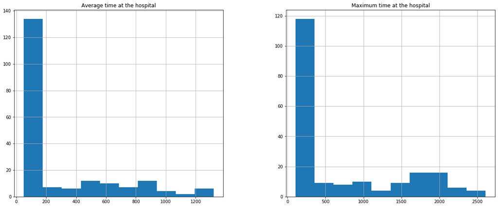

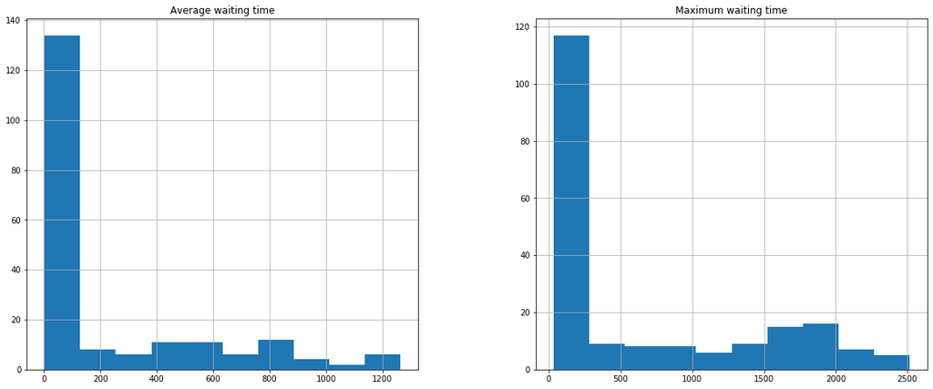

```python
df5.hist(column=['Average time at the hospital','Maximum time at the hospital'],figsize=(20,8))
df5.hist(column=['Average waiting time','Maximum waiting time'],figsize=(20,8))
```

#### All of the statistics are uni-modal and right skewed, and in nearly all of the graphs there’s no spike at the right or the extreme part, which indicates that there aren’t many higher values.

### Considering the Distribution of Average waiting time, 65% of the values lies between 0-200 minutes compared to the previous model, 900 to 1300 minutes accounts for the same proportion

## Distriubution of Probabilistic inputs of our model

```
array([[<matplotlib.axes._subplots.AxesSubplot object at 0x7fb7e86d2710>,
      dtype=object)
```

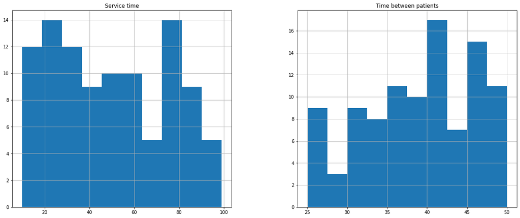

```python
df.hist(column=['Time between patients','Service time'],figsize=(20,8))
```